# Projet 10: "Détection des faux billets avec Python"

### Contexte du projet

<> L’Organisation nationale de lutte contre le faux-monnayage ( ONCFM), est une organisation publique ayant pour objectif de mettre en place des méthodes d’identification des contrefaçons des billets en euros. Dans le cadre de cette lutte, l’Organisation souhaite mettre en place un algorithme qui soit capable de différencier automatiquement les vrais des faux billets <>

### Objectifs

<> Lorsqu’un billet arrive, nous avons une machine qui consigne l’ensemble de ses caractéristiques géométriques. Tout au long des années de lutte, nous avons observé des différences de dimensions entre les vrais et les faux billets. Ces différences sont difficilement notables à l’œil nu, mais une machine devrait sans problème arriver à les différencier. Ainsi, il faudrait construire un algorithme qui, à partir des caractéristiques géométriques d’un billet, serait capable de définir si ce dernier est un vrai ou un faux billet <>.

### Fonctionnement général

<>Nous avons à notre disposition six données géométriques pour chaque billet. L’algorithme devra donc être capable de prendre en entrée un fichier contenant les dimensions de plusieurs billets, et de déterminer le type de chacun d’entre eux, à partir des seules dimensions<>

```python
# On importe les librairies dont on aura besoin pour la  modélisation
import pandas as pd
import numpy as np
import seaborn as sns
import matplotlib.pyplot as plt

# On charge le fichier 'billets'
billets = pd.read_csv('billets.csv')
billets.head()
```

|  | is_genuine | diagonal | height_left | height_right | margin_low | margin_up | length |
| --- | --- | --- | --- | --- | --- | --- | --- |
| 0 | True | 171.81 | 104.86 | 104.95 | 4.52 | 2.89 | 112.83 |
| 1 | True | 171.46 | 103.36 | 103.66 | 3.77 | 2.99 | 113.09 |
| 2 | True | 172.69 | 104.48 | 103.50 | 4.40 | 2.94 | 113.16 |
| 3 | True | 171.36 | 103.91 | 103.94 | 3.62 | 3.01 | 113.51 |
| 4 | True | 171.73 | 104.28 | 103.46 | 4.04 | 3.48 | 112.54 |

### 1. Préparation des données pour l'analyse

##### Une analyse descriptive des données

```python
billets.shape
```

```
(1500, 7)
```

```python
n_vrais_faux = billets.is_genuine.value_counts()
print(n_vrais_faux)
```

```
True     1000
False     500
Name: is_genuine, dtype: int64
```

```python
billets.nunique()
```

```
is_genuine        2
diagonal        159
height_left     155
height_right    170
margin_low      285
margin_up       123
length          336
dtype: int64
```

```python
billets.duplicated().sum()
```

```
0
```

```python
# détecter valeur manquent
billets.isna().sum()
```

```
is_genuine       0
diagonal         0
height_left      0
height_right     0
margin_low      37
margin_up        0
length           0
dtype: int64
```

###### Je vais remplacer les valeurs manquantes par des valeurs prédites en utilisent Regression Lineare

```python
# analyse descriptive des données :
billets.describe()
```

|  | diagonal | height_left | height_right | margin_low | margin_up | length |
| --- | --- | --- | --- | --- | --- | --- |
| count | 1500.000000 | 1500.000000 | 1500.000000 | 1463.000000 | 1500.000000 | 1500.00000 |
| mean | 171.958440 | 104.029533 | 103.920307 | 4.485967 | 3.151473 | 112.67850 |
| std | 0.305195 | 0.299462 | 0.325627 | 0.663813 | 0.231813 | 0.87273 |
| min | 171.040000 | 103.140000 | 102.820000 | 2.980000 | 2.270000 | 109.49000 |
| 25% | 171.750000 | 103.820000 | 103.710000 | 4.015000 | 2.990000 | 112.03000 |
| 50% | 171.960000 | 104.040000 | 103.920000 | 4.310000 | 3.140000 | 112.96000 |
| 75% | 172.170000 | 104.230000 | 104.150000 | 4.870000 | 3.310000 | 113.34000 |
| max | 173.010000 | 104.880000 | 104.950000 | 6.900000 | 3.910000 | 114.44000 |

##### Séparer les ligne avec des valeurs NULL et considérez-les comme 'test data'

```python
test_data=billets[billets["margin_low"].isnull()]
test_data
```

|  | is_genuine | diagonal | height_left | height_right | margin_low | margin_up | length |
| --- | --- | --- | --- | --- | --- | --- | --- |
| 72 | True | 171.94 | 103.89 | 103.45 | NaN | 3.25 | 112.79 |
| 99 | True | 171.93 | 104.07 | 104.18 | NaN | 3.14 | 113.08 |
| 151 | True | 172.07 | 103.80 | 104.38 | NaN | 3.02 | 112.93 |
| 197 | True | 171.45 | 103.66 | 103.80 | NaN | 3.62 | 113.27 |
| 241 | True | 171.83 | 104.14 | 104.06 | NaN | 3.02 | 112.36 |
| 251 | True | 171.80 | 103.26 | 102.82 | NaN | 2.95 | 113.22 |
| 284 | True | 171.92 | 103.83 | 103.76 | NaN | 3.23 | 113.29 |
| 334 | True | 171.85 | 103.70 | 103.96 | NaN | 3.00 | 113.36 |
| 410 | True | 172.56 | 103.72 | 103.51 | NaN | 3.12 | 112.95 |
| 413 | True | 172.30 | 103.66 | 103.50 | NaN | 3.16 | 112.95 |
| 445 | True | 172.34 | 104.42 | 103.22 | NaN | 3.01 | 112.97 |
| 481 | True | 171.81 | 103.53 | 103.96 | NaN | 2.71 | 113.99 |
| 505 | True | 172.01 | 103.97 | 104.05 | NaN | 2.98 | 113.65 |
| 611 | True | 171.80 | 103.68 | 103.49 | NaN | 3.30 | 112.84 |
| 654 | True | 171.97 | 103.69 | 103.54 | NaN | 2.70 | 112.79 |
| 675 | True | 171.60 | 103.85 | 103.91 | NaN | 2.56 | 113.27 |
| 710 | True | 172.03 | 103.97 | 103.86 | NaN | 3.07 | 112.65 |
| 739 | True | 172.07 | 103.74 | 103.76 | NaN | 3.09 | 112.41 |
| 742 | True | 172.14 | 104.06 | 103.96 | NaN | 3.24 | 113.07 |
| 780 | True | 172.41 | 103.95 | 103.79 | NaN | 3.13 | 113.41 |
| 798 | True | 171.96 | 103.84 | 103.62 | NaN | 3.01 | 114.44 |
| 844 | True | 171.62 | 104.14 | 104.49 | NaN | 2.99 | 113.35 |
| 845 | True | 172.02 | 104.21 | 104.05 | NaN | 2.90 | 113.62 |
| 871 | True | 171.37 | 104.07 | 103.75 | NaN | 3.07 | 113.27 |
| 895 | True | 171.81 | 103.68 | 103.80 | NaN | 2.98 | 113.82 |
| 919 | True | 171.92 | 103.68 | 103.45 | NaN | 2.58 | 113.68 |
| 945 | True | 172.09 | 103.74 | 103.52 | NaN | 3.02 | 112.78 |
| 946 | True | 171.63 | 103.87 | 104.66 | NaN | 3.27 | 112.68 |
| 981 | True | 172.02 | 104.23 | 103.72 | NaN | 2.99 | 113.37 |
| 1076 | False | 171.57 | 104.27 | 104.44 | NaN | 3.21 | 111.87 |
| 1121 | False | 171.40 | 104.38 | 104.19 | NaN | 3.17 | 112.39 |
| 1176 | False | 171.59 | 104.05 | 103.94 | NaN | 3.02 | 111.29 |
| 1303 | False | 172.17 | 104.49 | 103.76 | NaN | 2.93 | 111.21 |
| 1315 | False | 172.08 | 104.15 | 104.17 | NaN | 3.40 | 112.29 |
| 1347 | False | 171.72 | 104.46 | 104.12 | NaN | 3.61 | 110.31 |
| 1435 | False | 172.66 | 104.33 | 104.41 | NaN | 3.56 | 111.47 |
| 1438 | False | 171.90 | 104.28 | 104.29 | NaN | 3.24 | 111.49 |

```python
test_data.shape
```

```
(37, 7)
```

##### Supprimer les ligne avec des valeurs NULL de DataFrame et considérez-les comme **'train data'**

```python
billets.dropna(inplace=True)
billets
```

|  | is_genuine | diagonal | height_left | height_right | margin_low | margin_up | length |
| --- | --- | --- | --- | --- | --- | --- | --- |
| 0 | True | 171.81 | 104.86 | 104.95 | 4.52 | 2.89 | 112.83 |
| 1 | True | 171.46 | 103.36 | 103.66 | 3.77 | 2.99 | 113.09 |
| 2 | True | 172.69 | 104.48 | 103.50 | 4.40 | 2.94 | 113.16 |
| 3 | True | 171.36 | 103.91 | 103.94 | 3.62 | 3.01 | 113.51 |
| 4 | True | 171.73 | 104.28 | 103.46 | 4.04 | 3.48 | 112.54 |
| ... | ... | ... | ... | ... | ... | ... | ... |
| 1495 | False | 171.75 | 104.38 | 104.17 | 4.42 | 3.09 | 111.28 |
| 1496 | False | 172.19 | 104.63 | 104.44 | 5.27 | 3.37 | 110.97 |
| 1497 | False | 171.80 | 104.01 | 104.12 | 5.51 | 3.36 | 111.95 |
| 1498 | False | 172.06 | 104.28 | 104.06 | 5.17 | 3.46 | 112.25 |
| 1499 | False | 171.47 | 104.15 | 103.82 | 4.63 | 3.37 | 112.07 |

1463 rows × 7 columns

```python
# la taille du tableau
billets.shape
```

```
(1463, 7)
```

```python
# vérifier les valeurs manquantes
billets.isnull().sum()
```

```
is_genuine      0
diagonal        0
height_left     0
height_right    0
margin_low      0
margin_up       0
length          0
dtype: int64
```

##### Créer x_train et y_train à partir de nouveau DataFrame

```python
# nous séparons la colonne 'margin_low' pour 'y_train'
y_train=billets["margin_low"]
```

```python
y_train
```

```
0       4.52
1       3.77
2       4.40
3       3.62
4       4.04
        ...
1495    4.42
1496    5.27
1497    5.51
1498    5.17
1499    4.63
Name: margin_low, Length: 1463, dtype: float64
```

```python
# la taille de data set
y_train.shape
```

```
(1463,)
```

```python
# et crée 'x_train' - dataset sans "margin_low"
x_train=billets.drop("margin_low",axis=1)
```

```python
# la taille de data set
x_train.shape
```

```
(1463, 6)
```

##### Construire le modèle

-> préparer le modèle (Lineare Regression) pour prédire les valeurs manquantes dans la colonne "margin_low"

```python
# import Linear Regression depuit sklearn
from sklearn.linear_model import LinearRegression

# créer un modèle Regression Linear
linr = LinearRegression()

# entrainer model en data set 'train'
linr.fit(x_train,y_train)
```

```
LinearRegression()
```

##### Créer x_test a partire de test_data

```python
# 'x_test' signifie dataset sauf "margin_low"  avec les valeures NULL
X_test=test_data.drop("margin_low",axis=1)
X_test
```

|  | is_genuine | diagonal | height_left | height_right | margin_up | length |
| --- | --- | --- | --- | --- | --- | --- |
| 72 | True | 171.94 | 103.89 | 103.45 | 3.25 | 112.79 |
| 99 | True | 171.93 | 104.07 | 104.18 | 3.14 | 113.08 |
| 151 | True | 172.07 | 103.80 | 104.38 | 3.02 | 112.93 |
| 197 | True | 171.45 | 103.66 | 103.80 | 3.62 | 113.27 |
| 241 | True | 171.83 | 104.14 | 104.06 | 3.02 | 112.36 |
| 251 | True | 171.80 | 103.26 | 102.82 | 2.95 | 113.22 |
| 284 | True | 171.92 | 103.83 | 103.76 | 3.23 | 113.29 |
| 334 | True | 171.85 | 103.70 | 103.96 | 3.00 | 113.36 |
| 410 | True | 172.56 | 103.72 | 103.51 | 3.12 | 112.95 |
| 413 | True | 172.30 | 103.66 | 103.50 | 3.16 | 112.95 |
| 445 | True | 172.34 | 104.42 | 103.22 | 3.01 | 112.97 |
| 481 | True | 171.81 | 103.53 | 103.96 | 2.71 | 113.99 |
| 505 | True | 172.01 | 103.97 | 104.05 | 2.98 | 113.65 |
| 611 | True | 171.80 | 103.68 | 103.49 | 3.30 | 112.84 |
| 654 | True | 171.97 | 103.69 | 103.54 | 2.70 | 112.79 |
| 675 | True | 171.60 | 103.85 | 103.91 | 2.56 | 113.27 |
| 710 | True | 172.03 | 103.97 | 103.86 | 3.07 | 112.65 |
| 739 | True | 172.07 | 103.74 | 103.76 | 3.09 | 112.41 |
| 742 | True | 172.14 | 104.06 | 103.96 | 3.24 | 113.07 |
| 780 | True | 172.41 | 103.95 | 103.79 | 3.13 | 113.41 |
| 798 | True | 171.96 | 103.84 | 103.62 | 3.01 | 114.44 |
| 844 | True | 171.62 | 104.14 | 104.49 | 2.99 | 113.35 |
| 845 | True | 172.02 | 104.21 | 104.05 | 2.90 | 113.62 |
| 871 | True | 171.37 | 104.07 | 103.75 | 3.07 | 113.27 |
| 895 | True | 171.81 | 103.68 | 103.80 | 2.98 | 113.82 |
| 919 | True | 171.92 | 103.68 | 103.45 | 2.58 | 113.68 |
| 945 | True | 172.09 | 103.74 | 103.52 | 3.02 | 112.78 |
| 946 | True | 171.63 | 103.87 | 104.66 | 3.27 | 112.68 |
| 981 | True | 172.02 | 104.23 | 103.72 | 2.99 | 113.37 |
| 1076 | False | 171.57 | 104.27 | 104.44 | 3.21 | 111.87 |
| 1121 | False | 171.40 | 104.38 | 104.19 | 3.17 | 112.39 |
| 1176 | False | 171.59 | 104.05 | 103.94 | 3.02 | 111.29 |
| 1303 | False | 172.17 | 104.49 | 103.76 | 2.93 | 111.21 |
| 1315 | False | 172.08 | 104.15 | 104.17 | 3.40 | 112.29 |
| 1347 | False | 171.72 | 104.46 | 104.12 | 3.61 | 110.31 |
| 1435 | False | 172.66 | 104.33 | 104.41 | 3.56 | 111.47 |
| 1438 | False | 171.90 | 104.28 | 104.29 | 3.24 | 111.49 |

```python
X_test.shape
```

```
(37, 6)
```

##### Appliquer le modèle entraîné pour prédire les valeurs manquantes

```python
# appliquer le modèle trained sur x_test
y_pred=linr.predict(X_test)
y_pred
```

```
array([4.06495361, 4.11199026, 4.13400328, 3.99357074, 4.1403993 ,
       4.09428392, 4.07412432, 4.12538999, 4.0807278 , 4.07363322,
       4.11897255, 4.18037978, 4.13648423, 4.05106842, 4.17837685,
       4.22555104, 4.11586845, 4.10284101, 4.08184346, 4.09276238,
       4.11250192, 4.15717623, 4.16028787, 4.12193808, 4.12353555,
       4.19842271, 4.10962313, 4.09696025, 4.13384101, 5.25968515,
       5.264817  , 5.28251853, 5.30206887, 5.20035843, 5.1754678 ,
       5.17345045, 5.24675055])
```

```python
y_pred.shape
```

```
(37,)
```

##### Remplacer les valeurs manquantes par des valeurs prédites

```python
test_data.loc[test_data.margin_low.isnull(), "margin_low"]=y_pred
```

```python
test_data
```

|  | is_genuine | diagonal | height_left | height_right | margin_low | margin_up | length |
| --- | --- | --- | --- | --- | --- | --- | --- |
| 72 | True | 171.94 | 103.89 | 103.45 | 4.064954 | 3.25 | 112.79 |
| 99 | True | 171.93 | 104.07 | 104.18 | 4.111990 | 3.14 | 113.08 |
| 151 | True | 172.07 | 103.80 | 104.38 | 4.134003 | 3.02 | 112.93 |
| 197 | True | 171.45 | 103.66 | 103.80 | 3.993571 | 3.62 | 113.27 |
| 241 | True | 171.83 | 104.14 | 104.06 | 4.140399 | 3.02 | 112.36 |
| 251 | True | 171.80 | 103.26 | 102.82 | 4.094284 | 2.95 | 113.22 |
| 284 | True | 171.92 | 103.83 | 103.76 | 4.074124 | 3.23 | 113.29 |
| 334 | True | 171.85 | 103.70 | 103.96 | 4.125390 | 3.00 | 113.36 |
| 410 | True | 172.56 | 103.72 | 103.51 | 4.080728 | 3.12 | 112.95 |
| 413 | True | 172.30 | 103.66 | 103.50 | 4.073633 | 3.16 | 112.95 |
| 445 | True | 172.34 | 104.42 | 103.22 | 4.118973 | 3.01 | 112.97 |
| 481 | True | 171.81 | 103.53 | 103.96 | 4.180380 | 2.71 | 113.99 |
| 505 | True | 172.01 | 103.97 | 104.05 | 4.136484 | 2.98 | 113.65 |
| 611 | True | 171.80 | 103.68 | 103.49 | 4.051068 | 3.30 | 112.84 |
| 654 | True | 171.97 | 103.69 | 103.54 | 4.178377 | 2.70 | 112.79 |
| 675 | True | 171.60 | 103.85 | 103.91 | 4.225551 | 2.56 | 113.27 |
| 710 | True | 172.03 | 103.97 | 103.86 | 4.115868 | 3.07 | 112.65 |
| 739 | True | 172.07 | 103.74 | 103.76 | 4.102841 | 3.09 | 112.41 |
| 742 | True | 172.14 | 104.06 | 103.96 | 4.081843 | 3.24 | 113.07 |
| 780 | True | 172.41 | 103.95 | 103.79 | 4.092762 | 3.13 | 113.41 |
| 798 | True | 171.96 | 103.84 | 103.62 | 4.112502 | 3.01 | 114.44 |
| 844 | True | 171.62 | 104.14 | 104.49 | 4.157176 | 2.99 | 113.35 |
| 845 | True | 172.02 | 104.21 | 104.05 | 4.160288 | 2.90 | 113.62 |
| 871 | True | 171.37 | 104.07 | 103.75 | 4.121938 | 3.07 | 113.27 |
| 895 | True | 171.81 | 103.68 | 103.80 | 4.123536 | 2.98 | 113.82 |
| 919 | True | 171.92 | 103.68 | 103.45 | 4.198423 | 2.58 | 113.68 |
| 945 | True | 172.09 | 103.74 | 103.52 | 4.109623 | 3.02 | 112.78 |
| 946 | True | 171.63 | 103.87 | 104.66 | 4.096960 | 3.27 | 112.68 |
| 981 | True | 172.02 | 104.23 | 103.72 | 4.133841 | 2.99 | 113.37 |
| 1076 | False | 171.57 | 104.27 | 104.44 | 5.259685 | 3.21 | 111.87 |
| 1121 | False | 171.40 | 104.38 | 104.19 | 5.264817 | 3.17 | 112.39 |
| 1176 | False | 171.59 | 104.05 | 103.94 | 5.282519 | 3.02 | 111.29 |
| 1303 | False | 172.17 | 104.49 | 103.76 | 5.302069 | 2.93 | 111.21 |
| 1315 | False | 172.08 | 104.15 | 104.17 | 5.200358 | 3.40 | 112.29 |
| 1347 | False | 171.72 | 104.46 | 104.12 | 5.175468 | 3.61 | 110.31 |
| 1435 | False | 172.66 | 104.33 | 104.41 | 5.173450 | 3.56 | 111.47 |
| 1438 | False | 171.90 | 104.28 | 104.29 | 5.246751 | 3.24 | 111.49 |

##### Évaluation du modèle

```python
from sklearn.metrics import r2_score
```

```python
Y_test=test_data["margin_low"]
```

```python
# score R carré du modèle
r2_ = r2_score(Y_test, y_pred)
print("La performance du Modèle pour le set de Test")
print("--------------------------------------------")
print('le score R2 score est {}'.format(r2_))
```

```
La performance du Modèle pour le set de Test
--------------------------------------------
le score R2 score est 1.0
```

```python
test_data.shape
```

```
(37, 7)
```

```python
billets.isna().sum()
```

```
is_genuine      0
diagonal        0
height_left     0
height_right    0
margin_low      0
margin_up       0
length          0
dtype: int64
```

```python
billets.shape
```

```
(1463, 7)
```

##### Une concaténation de dataframe 'billets' avec 'test_data' qui contient les valeurs qui ont remplacé les valeurs manquantes

```python
frames=[billets,test_data]
bill=pd.concat(frames)
bill.shape
```

```
(1500, 7)
```

```python
bill.isna().sum()
```

```
is_genuine      0
diagonal        0
height_left     0
height_right    0
margin_low      0
margin_up       0
length          0
dtype: int64
```

###### Maintenant que nos données sont prêtes, nous pouvons passer à la modélisation

## 2. Modelisation

### 2.1 Algorithme k-NN avec Scikit-Learn (model de Classification)

-> Commencons par l'Algorithme k-NN

#### Préparation des variables pour le modèle

```python
# on divise notre tableau on X et Y
x=bill.drop("is_genuine",axis=1)
x.shape # la taille de data set X
```

```
(1500, 6)
```

```python
# on sépare la colonne 'is_genuine'
y=bill["is_genuine"]
y.shape # # la taille de data set Y
```

```
(1500,)
```

```python
# Séparez training / testing set a l'aide de 'train_test_split'
from sklearn.model_selection import train_test_split
xtrain, xtest, ytrain, ytest = train_test_split(x, y, train_size=0.8) # le modèle prend 80% pour train set et 20% pour test
```

#### Création et Entraînement du modèle de Classification

```python
# import 'Neighbors' depuit sklearn
from sklearn import neighbors

# Initialiser notre model.
knn = neighbors.KNeighborsClassifier(n_neighbors=4) # Selectionner un estimateur
knn.fit(xtrain, ytrain) # entrainer le modèle
```

```
KNeighborsClassifier(n_neighbors=4)
```

- l'algorithme ici n'effectue aucune optimisation mais va juste sauvegarder toutes les données en mémoire. C'est sa manière d'apprendre en quelque sorte.

```python
# On pourrait utiliser la methode predict qui obtient des prédictions sur les données de test
knn.predict(xtest)
print(knn.predict(xtest))
print(knn.predict_proba(xtest)) # calculer la probabilité, si les billets ont les caractéristiques False ou True
```

```
[ True False  True False False  True  True  True  True  True  True  True
  True  True False  True  True  True  True  True  True  True  True  True
 False False  True False  True  True False  True False  True False  True
 False  True False  True  True  True  True  True  True False  True  True
  True  True False  True  True  True False  True  True  True  True  True
  True False False  True  True False  True False False  True  True  True
  True False  True  True  True  True  True  True False  True  True False
  True False False  True  True False False False  True  True  True  True
  True False False  True False False  True  True  True  True False False
  True  True False False  True  True  True  True False  True  True  True
  True  True  True  True False  True  True  True  True  True  True  True
  True  True False  True  True  True False  True  True False False  True
  True  True  True False False  True  True False  True False  True  True
  True  True  True False False False  True  True  True  True False  True
 False  True False  True False False  True False False  True  True False
  True  True False False  True  True  True False  True  True  True False
  True  True  True  True  True  True  True False False  True  True  True
  True  True False  True  True  True  True False  True  True  True  True
  True  True  True  True  True  True  True  True  True  True False  True
  True  True False False  True False  True False False False  True False
 False  True  True False False  True  True  True False  True False  True
 False False False  True False False  True False False  True False  True
  True False  True False  True False  True  True False  True  True False
  True False  True  True False  True False  True  True False False False
  True False False False  True  True  True  True  True  True  True  True]
[[0.   1.  ]
 [1.   0.  ]
 [0.   1.  ]
 [1.   0.  ]
 [1.   0.  ]
 [0.   1.  ]
 [0.   1.  ]
 [0.   1.  ]
 [0.   1.  ]
 [0.   1.  ]
 [0.   1.  ]
 [0.   1.  ]
 [0.   1.  ]
 [0.   1.  ]
 [1.   0.  ]
```

[output cut: 270 more lines]

```
 [1.   0.  ]
 [1.   0.  ]
 [1.   0.  ]
 [0.   1.  ]
 [1.   0.  ]
 [1.   0.  ]
 [1.   0.  ]
 [0.   1.  ]
 [0.   1.  ]
 [0.   1.  ]
 [0.   1.  ]
 [0.   1.  ]
 [0.   1.  ]
 [0.   1.  ]
 [0.   1.  ]]
```

#### Évaluation du modèle

```python
# Testons à présent l’erreur de notre classifieur
error = 1 - knn.score(xtest, ytest)
print('Erreur: %f' % error)
```

```
Erreur: 0.003333
```

```python
# évaluer les performances de notre modèle
knn.score(xtrain, ytrain)
```

```
0.9908333333333333
```

- Le résultat est très bon déjà !

-> La performance exacte de notre modèle dépend du jeu de sélection. On peut lancer plusieurs fois ce traitement en changeant les jeux de données d'apprentissage et de test .

#### Optimisation du score sur les données test

-> Le k (nombre de voisins) est l'hyper-paramètre que l’on va chercher à optimiser, pour minimiser l’erreur sur les données test.

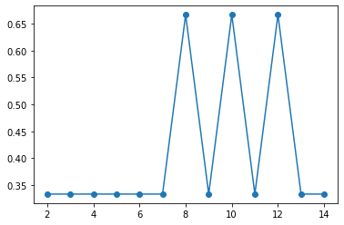

```python
# Optimisation du score sur les données test
errors = []
for k in range(2,15):
    knn = neighbors.KNeighborsClassifier(k)
    errors.append(100*(1 - knn.fit(xtrain, ytrain).score(xtest, ytest)))
plt.plot(range(2,15), errors, 'o-')
plt.show()
```

- Pour notre cas, le nombre de voisins 4 est optimal et c'est ce que j'ai choisi pour initialiser le modèle

#### Verification d'algoritme avec nouveau dataset ' billets_production' pour voir s'il fonctionne bien

```python
bi = pd.read_csv('billets_production.csv')
bi.head()
```

|  | diagonal | height_left | height_right | margin_low | margin_up | length | id |
| --- | --- | --- | --- | --- | --- | --- | --- |
| 0 | 171.76 | 104.01 | 103.54 | 5.21 | 3.30 | 111.42 | A_1 |
| 1 | 171.87 | 104.17 | 104.13 | 6.00 | 3.31 | 112.09 | A_2 |
| 2 | 172.00 | 104.58 | 104.29 | 4.99 | 3.39 | 111.57 | A_3 |
| 3 | 172.49 | 104.55 | 104.34 | 4.44 | 3.03 | 113.20 | A_4 |
| 4 | 171.65 | 103.63 | 103.56 | 3.77 | 3.16 | 113.33 | A_5 |

```python
i=bi.drop("id",axis=1)
i.shape
```

```
(5, 6)
```

```python
# convertir nouveau dataset en 'test'
xtest=i
```

```python
# utiliser la methode predict
print(knn.predict(xtest))
print(knn.predict_proba(xtest))
```

```
[False False False  True  True]
[[1. 0.]
 [1. 0.]
 [1. 0.]
 [0. 1.]
 [0. 1.]]
```

- Le Resultat de Teste: les 3 premiers tickets sont FAUX, les 2 suivants sont VRAI

```
                                     ******************
```

###### Maintenant on peut envisager une autre méthode de modélisation

## 2.2 La Régression Logictique avec Scikit-Learn

-> Puisqu'il faut expliquer les variable qualitative à partir de variables explicatives quantitatives, nous pouvons appliquer ici un type de modélisation:

- **la Classification supervisée ( ou régression logistique)**

-> Ci-dessous voyons comment nous allons tester notre modèle avec la régression loqistique :

### 2.2.1 Préparation des variables pour le modèle

```python
# import  Regression Logistic depuit sklearn
from sklearn.linear_model import LogisticRegression

# créer un modèle Regression Logistique
LogisticRegression(C=1.0,class_weight=None, dual=False, fit_intercept=True,
                   intercept_scaling=1,l1_ratio=None, max_iter=100,
                   multi_class='auto', n_jobs=None, penalty=12,
                   random_state=None, solver='lbfgs', tol=0.0001,
                   verbose=0, warm_start=False)
lr = LogisticRegression()
```

```python
# nous divisons notre tableau en X et Y
x1=bill.drop("is_genuine",axis=1) # on sépare la colonne 'is_genuine'
y1=bill["is_genuine"]
```

```python
# la taille de data set X
x1.shape
```

```
(1500, 6)
```

```python
# la taille de data set Y
y1.shape
```

```
(1500,)
```

```python
# Séparez training / testing set
x1train, x1test, y1train, y1test = train_test_split(x1, y1, train_size=0.8)
```

### 2.2.2 Entraînement du modèle

```python
# fit data
lr.fit(x1train,y1train)
```

```
LogisticRegression()
```

### 2.2.3 Appliquation le modèle

```python
# faire des prédictions sur les données de test
prediction=lr.predict(x1test)
prediction
```

```
array([False,  True, False,  True,  True,  True,  True,  True,  True,
        True, False,  True,  True, False,  True, False,  True,  True,
        True,  True,  True,  True,  True, False, False,  True, False,
        True,  True, False, False,  True,  True,  True, False, False,
        True,  True, False,  True, False,  True,  True,  True,  True,
       False, False,  True,  True,  True, False, False,  True,  True,
        True,  True, False,  True,  True,  True,  True,  True,  True,
       False,  True, False,  True,  True,  True,  True, False, False,
        True, False,  True, False,  True,  True, False,  True,  True,
        True,  True,  True,  True,  True,  True, False,  True,  True,
        True,  True, False,  True,  True, False,  True,  True, False,
        True, False,  True,  True,  True,  True, False,  True,  True,
        True,  True,  True,  True,  True,  True,  True,  True,  True,
       False,  True,  True,  True, False, False, False,  True,  True,
        True,  True, False,  True,  True,  True,  True,  True,  True,
       False, False,  True, False,  True, False, False,  True, False,
        True,  True,  True,  True,  True,  True, False, False,  True,
       False,  True, False, False,  True,  True,  True,  True,  True,
        True,  True,  True,  True, False,  True,  True,  True,  True,
        True,  True,  True,  True,  True, False,  True, False,  True,
        True,  True,  True, False,  True,  True, False,  True,  True,
       False,  True,  True,  True,  True,  True,  True,  True, False,
        True,  True,  True,  True,  True, False, False, False,  True,
        True,  True,  True, False, False, False, False,  True, False,
        True,  True, False,  True, False,  True,  True,  True,  True,
       False,  True, False,  True, False,  True, False, False,  True,
        True,  True,  True,  True, False,  True, False,  True, False,
        True,  True, False,  True, False,  True, False,  True, False,
        True, False,  True, False,  True, False, False,  True,  True,
       False,  True,  True, False,  True, False,  True,  True, False,
        True,  True, False,  True,  True,  True, False,  True,  True,
        True,  True,  True,  True,  True,  True,  True, False,  True,
        True,  True, False,  True,  True,  True,  True, False, False,
        True,  True,  True])
```

### 2.2.4 Évaluation les modèle avec des classification métriques 'Accuracy ' et 'F-score'

#### ! C'est une étape importante dans tout machine learning modele, qui consiste à évaluer la précision du modèle.

#### Les métriques : 'Accuracy ' et 'F-score' et Les métriques : Mean Squared Error, Mean absolute error, Root Mean Squared Error sont utilisées pour évaluer les performances du modèle dans l'analyse de régression.

-> **L’accuracy** est basée sur la matrice de confusion et répond à la question : combien d’individus ont été correctement prédits. Elle mesure le taux de prédictions correctes sur l’ensemble des individus

```python
from sklearn.metrics import accuracy_score
from sklearn.metrics import fbeta_score
print("Metric: Accuracy score: {:.4f}".format(accuracy_score(prediction,y1test)))
print('Metric: F-score', fbeta_score(prediction,y1test, average=None, beta=2))
```

```
Metric: Accuracy score: 0.9867
Metric: F-score [0.98468271 0.98753595]
```

- Nous avons ici **La justesse est 0.99 (soit 99 prédictions correctes sur 100 exemples au total)**. Cela signifie que notre modéle est très efficace pour identifier les vrais et faux billets.

  -> Mais cependant cette métrique doit être interprétée avec prudence en présence de données déséquilibrées . Donc on explore d’autres métriques de classification 'F-score' pour confirmer le résultat.

  -> **F-score** métriques accorde la même importance à **la precision et au recall**. Le taux de **précision** est un indice qui quantifie la quantité prevue correcte . Il est calculé en divisant le nombre d'exemples positifs prévus correct par le nombre total d'exemples positifs prévus.

**Recall** Est une mesure du nombre de prédictions positives correctes à partir de toutes les prédictions positives possibles .

### 2.2.5 Évaluation de la performence du modèle avec 'Mean_absolute_error' et 'Mean_squared_error' metriques

- J'ai continue l'Évaluation de la perforemence de notre modèle avec le mesure des erreurs à l'aide des métriques MAE et MSE.

-> **MAE (l'erreur absolue moyennere)** représente la moyenne de la différence absolue entre les valeurs réelles et prédites dans l'ensemble de données. Il mesure la moyenne des résidus.

**MSE (L'erreur quadratique moyenne)** représente la moyenne de la différence au carré entre les valeurs d'origine et prédites. Il mesure la variance des résidus.

**RMSE (Racine de l'erreur quadratique moyenne)** est la racine carrée de l'erreur quadratique moyenne. Il mesure l'écart type des résidus.

```python
from sklearn.metrics import mean_squared_error, mean_absolute_error, r2_score
# évaluation du modèle pour l'ensemble d'entraînement
y1test=y1test.astype(np.float32)
prediction=prediction.astype(np.float32)
mae=mean_absolute_error(y_true=y1test,y_pred=prediction)

# squared True renvoie la valeur MSE , Fals renvoie la valeur RMSE
mse= (mean_squared_error(y_true=y1test, y_pred=prediction)) #defaut =True
rmse = (mean_squared_error(y_true=y1test, y_pred=prediction, squared=False))

print("La performance du Modèle pour le set de Training")
print("------------------------------------------------")
print("Metric: [MAE: {:.4f}]".format(mae))
print("Metric: [MSE: {:.4f}]".format(mse))
print("Metric: [RMSE: {:.4f}]".format(rmse))
```

```
La performance du Modèle pour le set de Training
------------------------------------------------
Metric: [MAE: 0.0133]
Metric: [MSE: 0.0133]
Metric: [RMSE: 0.1155]
```

-> Le MAE et le RMSE peuvent être utilisés ensemble pour diagnostiquer la variation des erreurs.

-> Le RMSE sera toujours supérieur ou égal au MAE ; plus la différence entre eux est grande, plus la variance des erreurs individuelles est grande.

- Le MAE et le RMSE peuvent aller de 0 à l'infini. Ce sont des scores orientés négativement : les valeurs inférieures sont meilleures. **Dans notre cas, ce diagnostic donne un très bon résultat**.

### Pour l'évaluation optimale du modèle, il est possible avoir une analyse des nombres de faux positifs et faux négatifs via une Matrice de confusion.

-> La matrice de confusion est la base principale sur laquelle reposent toutes les métriques de classification : précision, score F1, courbe ROC, Précision-Rappel... Ainsi, la maîtriser est un pré-requis important pour comprendre comment évaluer les performances d'un modèle de classification.

-> C' est un outil de mesure de la performance des modèles de classification à 2 classes ou plus. Dans le cas binaire, la matrice de confusion est un tableau à 4 valeurs représentant les différentes combinaisons de valeurs réelles et valeurs prédites.

```python
from sklearn.metrics import confusion_matrix

matrix = confusion_matrix(y1test, prediction)
print(matrix)
```

```
[[ 90   3]
 [  1 206]]
```

```python
# Verification d'algoritme avec nouveau dataset ' billets_production'
x1test=i
print(lr.predict(x1test))
```

```
[False False False  True  True]
```

- Le Resultat de Teste: les 3 premiers billets sont FALSE, les 2 suivants sont TRUE. C'est le meme que dans la méthode précédente.

  **Les deux méthodes sont bien capable d’identifier automatiquement les vrais des faux billets, mais je préfère retenir la seconde comme modèle final en raison d'une évaluation plus solide avec les metriques appliquées**.

```python
new=pd.read_csv('billets_test.csv')
new
```

|  | diagonal | height_left | height_right | margin_low | margin_up | length | id |
| --- | --- | --- | --- | --- | --- | --- | --- |
| 0 | 172.09 | 103.95 | 103.73 | 4.39 | 3.09 | 113.19 | B_1 |
| 1 | 171.52 | 104.17 | 104.03 | 5.27 | 3.16 | 111.82 | B_2 |
| 2 | 171.78 | 103.80 | 103.75 | 3.81 | 3.24 | 113.39 | B_3 |
| 3 | 172.02 | 104.08 | 103.99 | 5.57 | 3.30 | 111.10 | B_4 |
| 4 | 171.79 | 104.34 | 104.37 | 5.00 | 3.07 | 111.87 | B_5 |

```python
new1=new.drop('id', axis=1)
new1.shape
```

```
(5, 6)
```

```python
x1test=new1
```

```python
print(lr.predict(x1test))
```

```
[ True False  True False False]
```

```python
print(lr.predict_proba(x1test))
```

```
[[1.03096295e-02 9.89690371e-01]
 [9.92351756e-01 7.64824354e-03]
 [8.21854268e-04 9.99178146e-01]
 [9.99851604e-01 1.48395520e-04]
 [9.87921315e-01 1.20786847e-02]]
```